# AS06_gender_b11704028吳昕祐

吳昕祐

2025-05-11

```r
knitr::opts_chunk$set(echo = TRUE)
```

## 台灣各縣市女性日間照顧服務需求人數佔總人數比例：女性需求高於男性，近兩年內東部與南部比例上升

name：日間照顧服務個案人數 資料範圍：2022-2024年 href：https://www.gender.ey.gov.tw/gecdb/Stat_Statistics_DetailData.aspx?sn=JhXdQCIVuVWrqa3tusWKbg%40%40&d=m9ww9odNZAz2Rc5Ooj%24wIQ%40%40 def:長期照顧十年計畫2.0－日間照顧服務服務個案人數(110年以後) cat1 縣市別 cat2 性別、長照需要等級

```r
library(tidyverse)
library(sf)
```

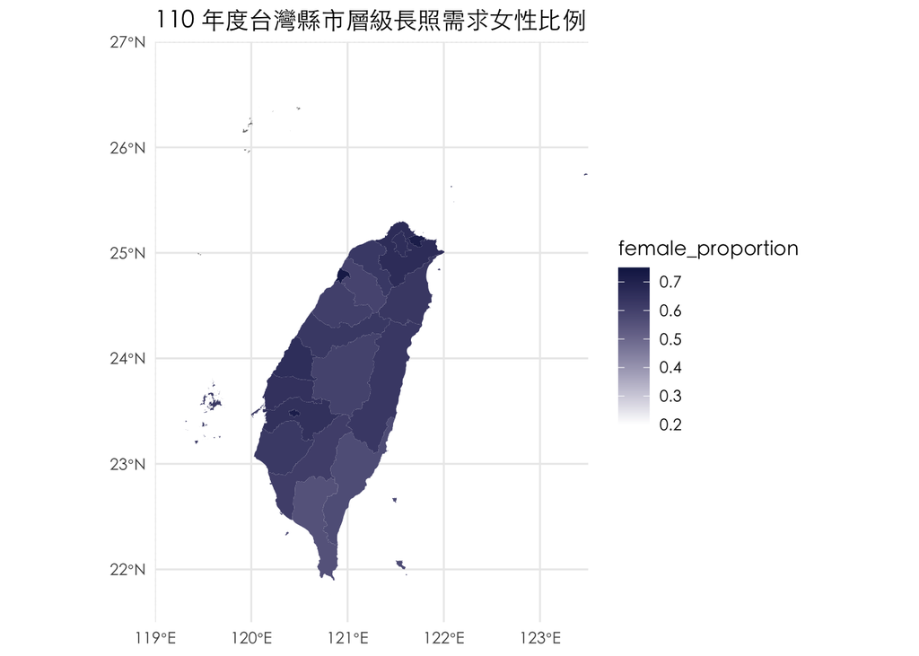

```r
library(tmap)
library(ggplot2)
library(dplyr)
library(readr)
library(jsonlite)
# 1. 讀 JSON + 整理資料
df <- fromJSON("/Users/hsinyu/Desktop/homecare20.json") %>%
  mutate(
    gender = Category1Title,
    district = Category2Title,
    level = Category3Title,
    year = Period / 100,
    number = Val
  ) %>%
  select(gender, district, level, year, number) %>%
  filter(grepl("總計", level)) %>%
  slice(-1)

# 2. 製作 male_table
male_table <- df %>%
  filter(gender == "男") %>%
  select(district, year, number) %>%
  rename(number_male = number)

# 3. 計算 male_proportion + female_proportion
df1 <- df %>%
  filter(gender == "總計") %>%
  left_join(male_table, by = c("district", "year")) %>%
  rename(number_total = number) %>%
  mutate(
    male_proportion = number_male / number_total,
    male_proportion = ifelse(is.nan(male_proportion), 0, male_proportion),
    female_proportion = 1 - male_proportion
  ) %>%
  drop_na(female_proportion) %>%
  mutate(district = gsub("台", "臺", district))  # 修正台/臺

# 4. 讀入 township 鄉鎮圖
township <- st_read("/Users/hsinyu/Downloads/taiwan_township_1140318/TOWN_MOI_1140318.shp")
# 5. 繪製110年度
df110 <- df1 %>% filter(year == 110)

county_map_110 <- township %>%
  group_by(COUNTYNAME) %>%
  summarise(geometry = st_union(geometry), .groups = 'drop') %>%
  left_join(df110 %>% select(district, female_proportion),
            by = c("COUNTYNAME" = "district"))

p110 <- ggplot(county_map_110) +
  geom_sf(aes(fill = female_proportion), color = NA) +
  scale_fill_gradient(low = "white", high = "#141F52",limits = c(0.2, 0.75)) +
  coord_sf(xlim = c(119, 123.5), ylim = c(21.5, 27), expand = FALSE) +
  ggtitle("110 年度台灣縣市層級長照需求女性比例") +
  theme_minimal() +
  theme(
    text = element_text(family = "Heiti TC Light"),
    title = element_text(family = "Heiti TC Light")
  )

# 6. 繪製112年度
df112 <- df1 %>% filter(year == 112)

county_map_112 <- township %>%
  group_by(COUNTYNAME) %>%
  summarise(geometry = st_union(geometry), .groups = 'drop') %>%
  left_join(df112 %>% select(district, female_proportion),
            by = c("COUNTYNAME" = "district"))

p112 <- ggplot(county_map_112) +
  geom_sf(aes(fill = female_proportion), color = NA) +
  scale_fill_gradient(low = "white", high = "#141F52",limits = c(0.2, 0.75)) +
  coord_sf(xlim = c(119, 123.5), ylim = c(21.5, 27), expand = FALSE) +
  ggtitle("112 年度台灣縣市層級長照需求女性比例") +
  theme_minimal() +
  theme(
    text = element_text(family = "Heiti TC Light"),
    title = element_text(family = "Heiti TC Light")
  )

# 7. 顯示結果
print(p110)
```

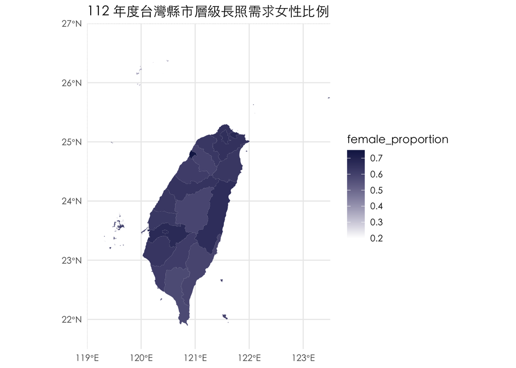

```r
print(p112)
```

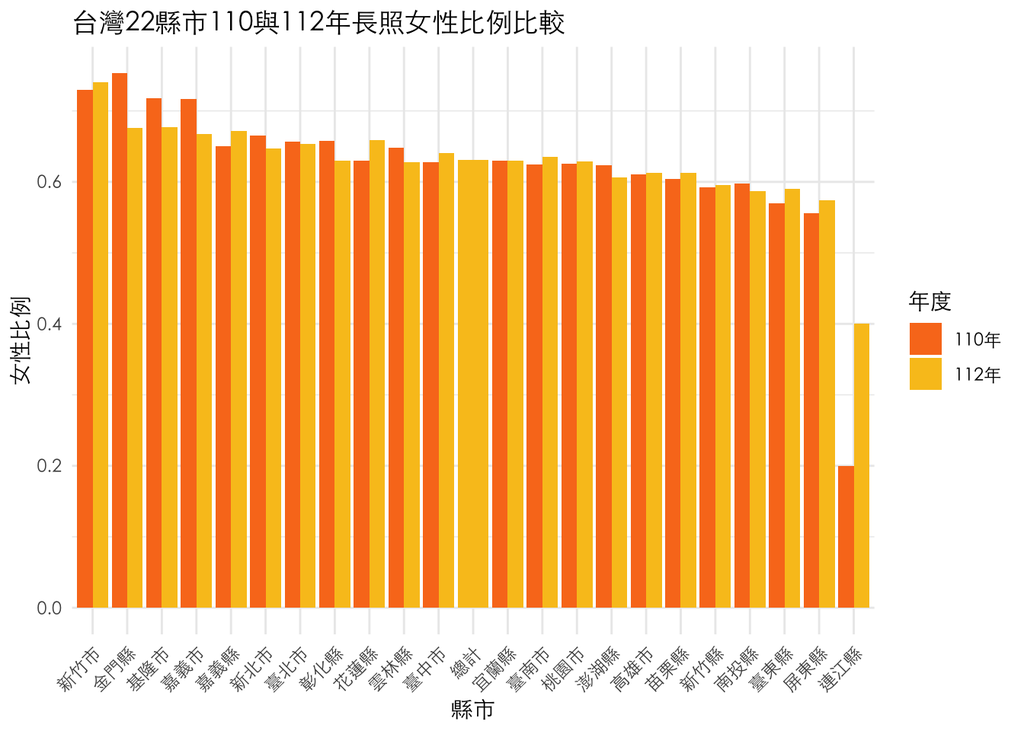

```r
library(ggplot2)
library(dplyr)

# 選擇 110年 + 112年資料
df_bar <- df1 %>%
  filter(year %in% c(110, 112)) %>%
  select(district, year, female_proportion) %>%
  mutate(year = as.factor(year))   # year 改成 factor 方便 ggplot 顏色分組

# 畫長條圖
ggplot(df_bar, aes(x = reorder(district, -female_proportion),
                   y = female_proportion,
                   fill = year)) +
  geom_bar(stat = "identity", position = "dodge") +
  scale_fill_manual(values = c("#F97A1F", "#F9C31F"),
                    name = "年度",
                    labels = c("110年", "112年")) +
  labs(title = "台灣22縣市110與112年長照女性比例比較",
       x = "縣市",
       y = "女性比例") +
  theme_minimal() +
  theme(
    axis.text.x = element_text(angle = 45, hjust = 1, family = "Heiti TC Light"),
    text = element_text(family = "Heiti TC Light"),
    title = element_text(family = "Heiti TC Light")
  )
```

不過，若只有這則資料，尚無法解釋過多資訊，若能夠串接人口組合資料（獨居、單親、婚姻狀態），將會有更好的解釋能力。